# Essence and Implementation of Camera Calibration

## Essence of Camera Calibration

### 1.Pinhole Camera Model

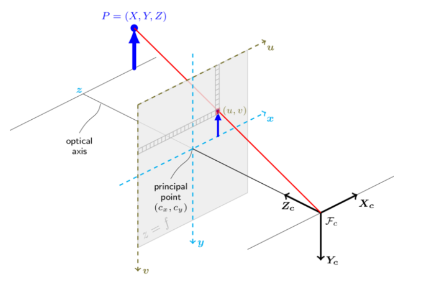

#### Coordination types :

1.World Coordination: P(X,Y,Z) The object position defined in the real world.  
2.Camera Coordination: (xc,yc,zc) x/y axis are paralle to the projection plane, Z axis is along the optical axis to forword. Orignal point lie on the optical axis.  
3.Image Coordination: (x,y) x/y plane lie on the projectiong plane,the orignal point is the intersection of optical axis and projection plane.  
4.Pixel Coordination: (u,v) u/v axis dirction coincide with image coordination x/y axis, The orignal point place on the upleft corner.(unit: pixel)

### Camera External Params

Purpose: World Coordination to Camera Coordination  
Include : R,T transform matrix.

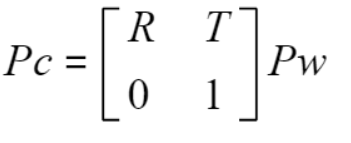

R is rotation matrix,T is translate matrix, Pc point in camera coordination, Pc point in world coordintion.

###### R rotaion matrix is a orthogonal matrix: https://blog.csdn.net/datase/article/details/74502958</br>

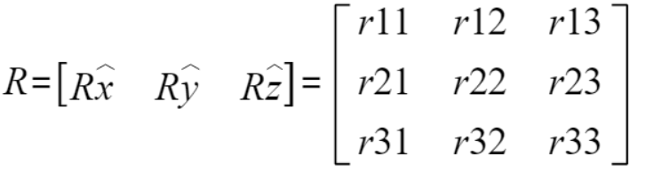

As Conclusion,Camera external parameters total inlude 6 variables, three rotation basic vector:Rx,Ry,Rz and three translation weight value:tx,ty,tz.

### Camera Intrisic Params

Purpose: Camera Coordination to Image Coordination to Pixel Coordination.  
Include: x/y scalar,focal length, principal point,γscrew (usually set it to zero).

##### Camera to image Coordination:

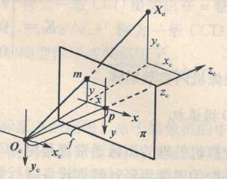

As follows, Pc = [Xc,Yc,Zc,1]T point in camera coordination, m = [Xp,Yp,1]T point in image coordintion, according to principle of similar triangle:

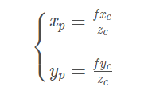

as matrix:

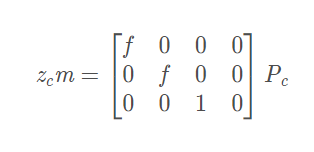

Princple pooint may not lie on the image coordination orignal point. Assume princple point p =[x0,y0,1]T in image coordination;  
then

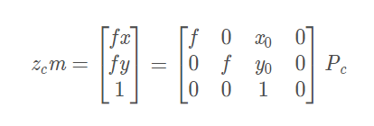

##### Camera to pixel coordination

Assume dx,dy is the pixel width and height. Pix = [u,v,1]T is a point in pixel coordination.

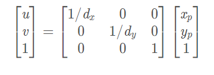

combin with camera to image coordintion's transform matrix:

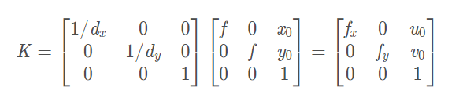

K is the transform matrix of camera to pixel coordintion,fx = f/dx,fy = f/dy are the scaling factor on u/v aixs in pixel coordintion. [u0,v0]T = [x0/dx,y0/dy] is the princple point in pixel coordination.

As conclusion, a point from world coordination to pixel coordination:

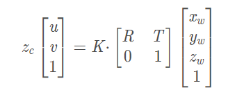

### Camera Distortion Parmas

Purpose: correction optical imaging distortion.  
Include: tangential distortion : p1,p2. radial distortion: k1,k2,k3

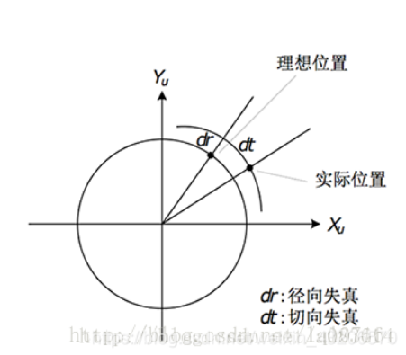

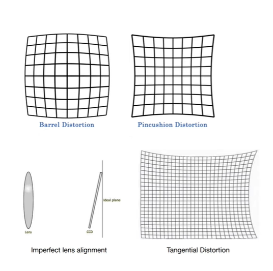

Rdial distortion (Barrel and Pincushion Distortion): Light away from optical center are more deflection. The correction formula:

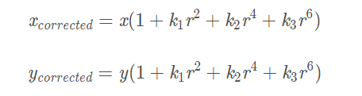

Tangential distortion: Imperfect lens alignment,not paralle with the image plane. The correction formula:

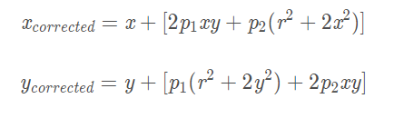

Here we get total 5 distortion parameters (k1,k2,k3,p1,p2).

### Summary

Camera calibration total include 16 parameters:  
Only camera related: 10 instric parameters:  
Camera to pixel: f,dx,dy,Xc,Yc; Distortion: radial(k1,k2,k3), tangential(p1,p2).  
Camera Pose in world coordination:  
Rotation: Rx,Ry,Rz;  
Translation: Tx,Ty,Tz;

## Implement of Camera Calibration With OpenCV in Python

```python
#Add necessary libaries
import cv2
import numpy as np
import glob

# grab calibration images from web camera
camera:cv2.VideoCapture = cv2.VideoCapture(0)
num = 0
while(1):
    ret, img = camera.read()
    cv2.imshow("test",img)

    if cv2.waitKey(10)&0xff == ord('s'):
        num += 1
        filename = "./CalImage/cal" + str(num) + ".jpg"
        cv2.imwrite(filename, img)
        print(filename + " saved!")
    if cv2.waitKey(10)&0xff == ord('q'):
        cv2.destroyAllWindows()
        camera.release()
        break
```

Grab at least ten images with different pose of chessboard. Run calibration code as follows:

```python
# termination criteria
criteria = (cv2.TERM_CRITERIA_EPS + cv2.TERM_CRITERIA_MAX_ITER, 30, 0.001)
# prepare object points, like (0,0,0), (1,0,0), (2,0,0) ....,(6,5,0)
objp = np.zeros((9*6,3), np.float32)
objp[:,:2] = np.mgrid[0:9,0:6].T.reshape(-1,2)
objpoints = [] #chessboard conner 3d points
imgpoints = [] #conners image point
imgPaths = glob.glob('D:\\GitRepos\\WORK\\self project\\LearnPython\\CalImage\\*.jpg')
for frame in imgPaths:
    img = cv2.imread(frame)
    imggray = cv2.cvtColor(img, cv2.COLOR_RGB2GRAY)
    # Find the chess board corners
    ret, corners = cv2.findChessboardCorners(imggray, (9,6), None)
    # If found, add object points, image points (after refining them)
    if ret == True:
        objpoints.append(objp)
        corners2 = cv2.cornerSubPix(imggray,corners, (11,11), (-1,-1), criteria)
        imgpoints.append(corners)
        # Draw and display the corners
        cv2.drawChessboardCorners(img, (9,6), corners2, ret)
        cv2.imshow('img', img)
        cv2.waitKey()
shape  = imggray.shape[::-1]
ret,cameraMatrix,dist,rvecs,tvecs = cv2.calibrateCamera(objpoints, imgpoints, shape ,None,None)
print("camera matrix :{}".format(cameraMatrix) )
print("distortion parameters :{}".format(dist) )

#optimal cameramatrix
imgT = cv2.imread('D:\\GitRepos\\WORK\\self project\\LearnPython\\CalImage\\cal1.jpg')
h,  w = imgT.shape[:2]
newcameramtx, roi = cv2.getOptimalNewCameraMatrix(cameraMatrix, dist, (w,h), 1, (w,h),True)
# undistort
dst = cv2.undistort(imgT, cameraMatrix, dist, None, newcameramtx)
# crop the image
x, y, w, h = roi
dst = dst[y:y+h, x:x+w]
cv2.imshow('img', dst)
cv2.waitKey()

#EMS-ERROR
mean_error = 0
for i in range(len(objpoints)):
    imgpoints2, _ = cv2.projectPoints(objpoints[i], rvecs[i], tvecs[i], cameraMatrix, dist)
    error = cv2.norm(imgpoints[i], imgpoints2, cv2.NORM_L2)/len(imgpoints2)
    mean_error += error
print( "total error: {}".format(mean_error/len(objpoints)) )

cv2.destroyAllWindows()
```

```
camera matrix :[[676.81613936   0.         317.89650461]
 [  0.         679.72578064 266.04589985]
 [  0.           0.           1.        ]]
distortion parameters :[[-0.03141416  0.24756646  0.00384778 -0.0008074  -0.45678929]]
total error: 0.02060147229382931
```

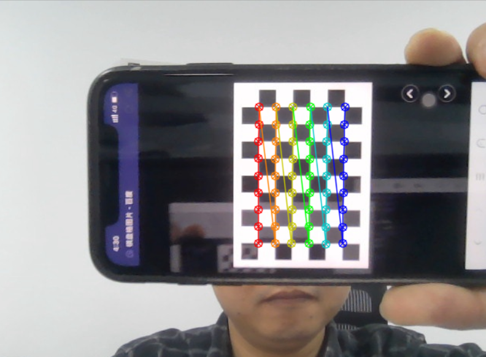